# AB_test_of_the_internet_store_income_change

## Описание проекта

"Вы работаете в стартапе, который продаёт продукты питания. Нужно разобраться, как ведут себя пользователи вашего мобильного приложения.

Изучите воронку продаж. Узнайте, как пользователи доходят до покупки. Сколько пользователей доходит до покупки, а сколько — «застревает» на предыдущих шагах? На каких именно?

После этого исследуйте результаты A/A/B-эксперимента. Дизайнеры захотели поменять шрифты во всём приложении, а менеджеры испугались, что пользователям будет непривычно. Договорились принять решение по результатам A/A/B-теста. Пользователей разбили на 3 группы: 2 контрольные со старыми шрифтами и одну экспериментальную — с новыми. Выясните, какой шрифт лучше."

### Оглавление

- Шаг 1. Откроем файл с данными и изучим общую информацию
- Шаг 2. Подготовим данные
- Шаг 3. Изучим и проверим данные
- Шаг 4. Изучим воронку событий
- Шаг 5. Изучим результаты эксперимента
- Выводы

```python
import pandas as pd
import numpy as np
import matplotlib.pyplot as plt
import plotly.express as px
import seaborn as sns
import math
import datetime
from IPython.display import display
from plotly import graph_objects as go
from scipy import stats as st
```

## Шаг 1. Откроем файл с данными и изучим общую информацию

Загрузим датасет `logs_exp`, выведем общую информацию и первые десять строк на экран.

```python
logs_exp = pd.read_csv('/datasets/logs_exp.csv', sep='\t')
```

```python
logs_exp.info()
```

```
<class 'pandas.core.frame.DataFrame'>
RangeIndex: 244126 entries, 0 to 244125
Data columns (total 4 columns):
EventName         244126 non-null object
DeviceIDHash      244126 non-null int64
EventTimestamp    244126 non-null int64
ExpId             244126 non-null int64
dtypes: int64(3), object(1)
memory usage: 7.5+ MB
```

```python
logs_exp.head(10)
```

|  | EventName | DeviceIDHash | EventTimestamp | ExpId |
| --- | --- | --- | --- | --- |
| 0 | MainScreenAppear | 4575588528974610257 | 1564029816 | 246 |
| 1 | MainScreenAppear | 7416695313311560658 | 1564053102 | 246 |
| 2 | PaymentScreenSuccessful | 3518123091307005509 | 1564054127 | 248 |
| 3 | CartScreenAppear | 3518123091307005509 | 1564054127 | 248 |
| 4 | PaymentScreenSuccessful | 6217807653094995999 | 1564055322 | 248 |
| 5 | CartScreenAppear | 6217807653094995999 | 1564055323 | 248 |
| 6 | OffersScreenAppear | 8351860793733343758 | 1564066242 | 246 |
| 7 | MainScreenAppear | 5682100281902512875 | 1564085677 | 246 |
| 8 | MainScreenAppear | 1850981295691852772 | 1564086702 | 247 |
| 9 | MainScreenAppear | 5407636962369102641 | 1564112112 | 246 |

Таблица `logs_exp` содержит следующие столбцы:

- `EventName` — название события;
- `DeviceIDHash` — уникальный идентификатор пользователя;
- `EventTimestamp` — время события;
- `ExpId` — номер эксперимента: 246 и 247 — контрольные группы, а 248 — экспериментальная.

### К оглавлению

## Шаг 2. Подготовим данные

Дататасет состоит из 4 столбцов и 244126 строк. Названия столбцов одностилевые, не стану их заменять.

Проверим на дубликаты.

```python
logs_exp.duplicated().sum()
```

```
413
```

Дубликаты составляют меньше 0,2% датасета, удалим их.

```python
logs_exp = logs_exp.drop_duplicates()
```

Пропуски отсутствуют. Изменим формат поля `ExpId` с `int64` на `int16`.

```python
logs_exp['ExpId'] = logs_exp['ExpId'].astype(np.int16())
```

Добавим столбец даты и времени, а также отдельный столбец дат методами `to_datetime` и `astype`.

```python
logs_exp['Datetime'] = pd.to_datetime(logs_exp['EventTimestamp'], unit='s')
logs_exp['Date'] = logs_exp['Datetime'].astype('datetime64[D]')
logs_exp.head()
```

|  | EventName | DeviceIDHash | EventTimestamp | ExpId | Datetime | Date |
| --- | --- | --- | --- | --- | --- | --- |
| 0 | MainScreenAppear | 4575588528974610257 | 1564029816 | 246 | 2019-07-25 04:43:36 | 2019-07-25 |
| 1 | MainScreenAppear | 7416695313311560658 | 1564053102 | 246 | 2019-07-25 11:11:42 | 2019-07-25 |
| 2 | PaymentScreenSuccessful | 3518123091307005509 | 1564054127 | 248 | 2019-07-25 11:28:47 | 2019-07-25 |
| 3 | CartScreenAppear | 3518123091307005509 | 1564054127 | 248 | 2019-07-25 11:28:47 | 2019-07-25 |
| 4 | PaymentScreenSuccessful | 6217807653094995999 | 1564055322 | 248 | 2019-07-25 11:48:42 | 2019-07-25 |

### К оглавлению

## Шаг 3. Изучим и проверим данные

Посчитаем, сколько всего событий в логе.

```python
logs_exp['EventName'].unique()
```

```
array(['MainScreenAppear', 'PaymentScreenSuccessful', 'CartScreenAppear',
       'OffersScreenAppear', 'Tutorial'], dtype=object)
```

```python
logs_exp.info()
```

```
<class 'pandas.core.frame.DataFrame'>
Int64Index: 243713 entries, 0 to 244125
Data columns (total 6 columns):
EventName         243713 non-null object
DeviceIDHash      243713 non-null int64
EventTimestamp    243713 non-null int64
ExpId             243713 non-null int16
Datetime          243713 non-null datetime64[ns]
Date              243713 non-null datetime64[ns]
dtypes: datetime64[ns](2), int16(1), int64(2), object(1)
memory usage: 11.6+ MB
```

**Вывод:** в датасете 243713 события, уникальных событий всего пять.

Посчитаем, сколько всего пользователей в логе.

```python
len(logs_exp['DeviceIDHash'].unique())
```

```
7551
```

**Вывод:** в логе всего 7551 пользователь.

Сгруппируем таблицу `logs_exp` по идентификаторам пользователей и посчитаем количество событий. Сохраним в переменную `user_eventnames`.

```python
user_eventnames = logs_exp.groupby('DeviceIDHash').agg({'EventName': 'count'})
user_eventnames.head()
```

| DeviceIDHash | EventName |
| --- | --- |
| 6888746892508752 | 1 |
| 6909561520679493 | 5 |
| 6922444491712477 | 47 |
| 7435777799948366 | 6 |
| 7702139951469979 | 137 |

Посчитаем, сколько в среднем событий приходится на пользователя.

```python
user_eventnames.mean()
```

```
EventName    32.275593
dtype: float64
```

**Вывод:** в среднем на пользователя приходится 32 события.

Исследуем количество пользовательских событий методом `describe()`.

```python
user_eventnames.describe()
```

|  | EventName |
| --- | --- |
| count | 7551.000000 |
| mean | 32.275593 |
| std | 65.154219 |
| min | 1.000000 |
| 25% | 9.000000 |
| 50% | 20.000000 |
| 75% | 37.000000 |
| max | 2307.000000 |

Найдём моду.

```python
user_eventnames.mode()
```

|  | EventName |
| --- | --- |
| 0 | 5 |

Построим гистограмму, ограничив события на одного пользователя значением 101.

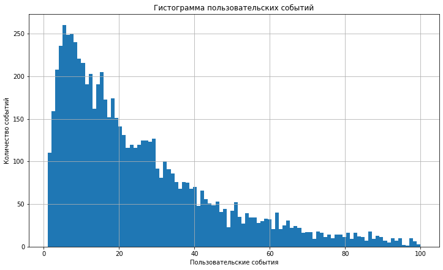

```python
user_eventnames[user_eventnames['EventName'] < 101].hist(bins=100, figsize=(12, 7))
plt.grid(True)
ax = plt.gca()
ax.set_xlabel('Пользовательские события')
ax.set_ylabel('Количество событий')
plt.title('Гистограмма пользовательских событий');
```

**Вывод:** чаще всего на пользователя приходится 5 событий. Распределение Пуассона.

Найдём максимальную и минимальную дату.

```python
logs_exp['Date'].min()
```

```
Timestamp('2019-07-25 00:00:00')
```

```python
logs_exp['Date'].max()
```

```
Timestamp('2019-08-07 00:00:00')
```

Сгруппируем таблицу `logs_exp` по дате, посчитаем количество пользовательских событий, сбросим индексы методом `reset_index()` и сохраним в переменную `logs_exp_date`. Преобразуем столбец `Date` в формат строки.

```python
logs_exp_date = logs_exp.groupby('Date').agg({'DeviceIDHash': 'count'}).reset_index()
logs_exp_date['Date'] = logs_exp_date['Date'].astype(str)
logs_exp_date
```

|  | Date | DeviceIDHash |
| --- | --- | --- |
| 0 | 2019-07-25 | 9 |
| 1 | 2019-07-26 | 31 |
| 2 | 2019-07-27 | 55 |
| 3 | 2019-07-28 | 105 |
| 4 | 2019-07-29 | 184 |
| 5 | 2019-07-30 | 412 |
| 6 | 2019-07-31 | 2030 |
| 7 | 2019-08-01 | 36141 |
| 8 | 2019-08-02 | 35554 |
| 9 | 2019-08-03 | 33282 |
| 10 | 2019-08-04 | 32968 |
| 11 | 2019-08-05 | 36058 |
| 12 | 2019-08-06 | 35788 |
| 13 | 2019-08-07 | 31096 |

Построим гистограмму.

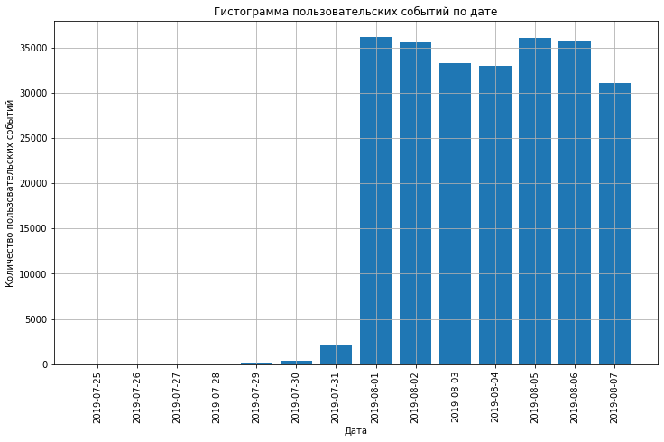

```python
plt.figure(figsize=(12, 7))
plt.bar(logs_exp_date['Date'], logs_exp_date['DeviceIDHash'])
plt.grid(True)
ax = plt.gca()
ax.set_xlabel('Дата')
ax.set_ylabel('Количество пользовательских событий')
ax.set_xticklabels(logs_exp_date['Date'], rotation = 90, verticalalignment = 'top')
plt.title('Гистограмма пользовательских событий по дате');
```

Отбросим июльские данные. Сохраним результат в переменную `logs_exp_filtered`.

```python
logs_exp_filtered = logs_exp[logs_exp['Date'] >= '2019-08-01']
```

**Вывод:** данные полны с 1-го августа 2019.

Посчитаем количество отброшенных событий и пользователей при помощи метода `shape`.

```python
logs_exp.shape[0] - logs_exp_filtered.shape[0]
```

```
2826
```

**Вывод:** количество отброшенных событий и пользователей составляет 1% данных.

Посчитаем количество пользователей из всех трёх экспериментальных групп в отброшенных данных и в полных.

```python
logs_exp[logs_exp['Date'] < '2019-08-01'].groupby('ExpId').agg({'DeviceIDHash': ['count', 'nunique']})
```

| ExpId | DeviceIDHash count | DeviceIDHash nunique |
| --- | --- | --- |
| 246 | 879 | 459 |
| 247 | 928 | 484 |
| 248 | 1019 | 508 |

```python
logs_exp[logs_exp['Date'] < '2019-08-01']['DeviceIDHash'].drop_duplicates().reset_index(drop = True)
```

```
0       4575588528974610257
1       7416695313311560658
2       3518123091307005509
3       6217807653094995999
4       8351860793733343758
               ...
1446    1879130487676858089
1447    5801359697252720810
1448     874398610899880804
1449    2238430701269950372
1450    2413191300976302222
Name: DeviceIDHash, Length: 1451, dtype: int64
```

```python
logs_exp_filtered['DeviceIDHash'].drop_duplicates().reset_index(drop = True)
```

```
0       3737462046622621720
1       1433840883824088890
2       4899590676214355127
3       1182179323890311443
4       4613461174774205834
               ...
7529    5811573131275421338
7530    5365227480683749189
7531    6660805781687343085
7532    7823752606740475984
7533    3454683894921357834
Name: DeviceIDHash, Length: 7534, dtype: int64
```

```python
np.setdiff1d(logs_exp[logs_exp['Date'] < '2019-08-01']['DeviceIDHash'].drop_duplicates().reset_index(drop = True), \
                 logs_exp_filtered['DeviceIDHash'].drop_duplicates().reset_index(drop = True))
```

```
array([  19151588103329050, 2141951348073372988, 2271703761362823687,
       2284191870135457477, 3551033798723561677, 3732627634014826395,
       4038665841336196550, 5114978858019388942, 5505110279185484837,
       6802370866140138742, 6991707383660138921, 7098993074549869464,
       7145262973832191693, 7539563624051296370, 8759002907241723567,
       8774423546023392346, 9192059464363071054])
```

```python
logs_exp_filtered.groupby('ExpId').agg({'DeviceIDHash': ['count', 'nunique']})
```

| ExpId | DeviceIDHash count | DeviceIDHash nunique |
| --- | --- | --- |
| 246 | 79302 | 2484 |
| 247 | 77022 | 2513 |
| 248 | 84563 | 2537 |

Найдём отношение.

```python
logs_exp[logs_exp['Date'] < '2019-08-01'].groupby('ExpId').agg({'DeviceIDHash': ['count', 'nunique']}) / \
logs_exp_filtered.groupby('ExpId').agg({'DeviceIDHash': ['count', 'nunique']})
```

| ExpId | DeviceIDHash count | DeviceIDHash nunique |
| --- | --- | --- |
| 246 | 0.011084 | 0.184783 |
| 247 | 0.012049 | 0.192598 |
| 248 | 0.012050 | 0.200236 |

**Вывод:** в полных данных есть пользователи из всех трёх экспериментальных групп.

**Вывод:** в логе всего 7551 пользователь, чаще всего на пользователя приходится 5 событий. Данные полны с 1-го августа 2019, в полных данных есть пользователи из всех трёх экспериментальных групп.

### К оглавлению

## Шаг 4. Изучим воронку событий

Посмотрим, какие события есть в логах:

- `MainScreenAppear` — переход на главную страницу;
- `OffersScreenAppear` — переход на страницу оформления заказа;
- `CartScreenAppear` — переход на страницу оплаты картой;
- `PaymentScreenSuccessful` — переход на страницу успешной оплаты;
- `Tutorial` — обучение.

Посчитаем, как часто встречаются события методом `value_counts()`.

```python
logs_exp_filtered['EventName'].value_counts()
```

```
MainScreenAppear           117328
OffersScreenAppear          46333
CartScreenAppear            42303
PaymentScreenSuccessful     33918
Tutorial                     1005
Name: EventName, dtype: int64
```

Создадим массив названий событий.

```python
EventName = ['Обучение', 'Успешная оплата', 'Оплата картой', 'Оформление заказа', 'Главная страница']
```

Построим гистограмму.

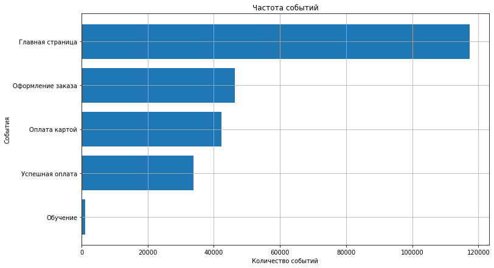

```python
plt.figure(figsize=(12, 7))
plt.barh(EventName, logs_exp_filtered['EventName'].value_counts(ascending=True))
ax = plt.gca()
plt.grid(True)
ax.set_xlabel('Количество событий')
ax.set_ylabel('События')
plt.title('Частота событий');
```

Аналогично найдём количество событий по числу пользователей. Сгруппируем таблицу `logs_exp_filtered` по событиям, посчитаем количество пользователей, отсортируем по убыванию методом `sort_values()`, сохраним в переменную `all_users`.

```python
all_users = logs_exp_filtered.groupby('EventName').agg({'DeviceIDHash': 'count'}).sort_values(
    by='DeviceIDHash', ascending=False)
all_users
```

| EventName | DeviceIDHash |
| --- | --- |
| MainScreenAppear | 117328 |
| OffersScreenAppear | 46333 |
| CartScreenAppear | 42303 |
| PaymentScreenSuccessful | 33918 |
| Tutorial | 1005 |

Посчитаем долю пользователей, которые хоть раз совершали событие. Сгруппируем таблицу `logs_exp_filtered` по событиям, посчитаем количество уникальных пользователей, отсортируем по убыванию методом `sort_values()`, сохраним в переменную `unique_users`.

```python
unique_users = logs_exp_filtered.groupby('EventName').agg({'DeviceIDHash': 'nunique'}).sort_values(
    by='DeviceIDHash', ascending=False)
unique_users
```

| EventName | DeviceIDHash |
| --- | --- |
| MainScreenAppear | 7419 |
| OffersScreenAppear | 4593 |
| CartScreenAppear | 3734 |
| PaymentScreenSuccessful | 3539 |
| Tutorial | 840 |

Построим гистограмму.

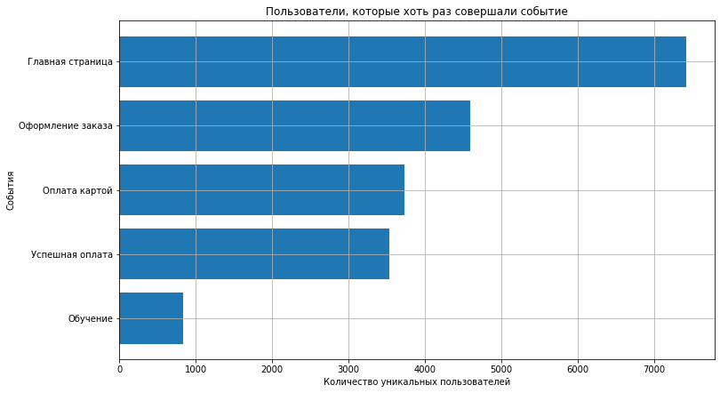

```python
plt.figure(figsize=(12, 7))
plt.barh(EventName, \
         unique_users.sort_values(by='DeviceIDHash', ascending=True)['DeviceIDHash'])
ax = plt.gca()
plt.grid(True)
ax.set_xlabel('Количество уникальных пользователей')
ax.set_ylabel('События')
plt.title('Пользователи, которые хоть раз совершали событие');
```

**Вывод:** пользователи чаще всего обновляют главную страницу, что вполне очевидно.

```python
all_users = all_users.drop('Tutorial')
```

Изменим массив названий событий.

```python
EventName = ['Главная страница', 'Оформление заказа', 'Оплата картой', 'Успешная оплата']
```

Построим воронку событий методом `Funnel()`.

```python
fig = go.Figure(go.Funnel(
    y = EventName,
    x = unique_users['DeviceIDHash'],
    ))
fig.show()
```

[interactive chart not shown]

Добавим в таблицу `unique_users` столбцы `Previous` и `Initial` с отформатированными значениями.

```python
unique_users['Previous'] = unique_users['DeviceIDHash'] / unique_users['DeviceIDHash'].shift()
unique_users['Previous'] = unique_users['Previous'].fillna(1)
unique_users['Previous'] = unique_users['Previous'].apply(lambda x: "{0:.1f}%".format(x * 100))

unique_users['Initial'] = unique_users['DeviceIDHash'] / unique_users.loc['MainScreenAppear', 'DeviceIDHash']
unique_users['Initial'] = unique_users['Initial'].apply(lambda x: "{0:.1f}%".format(x * 100))
unique_users = unique_users.drop('Tutorial')
unique_users
```

| EventName | DeviceIDHash | Previous | Initial |
| --- | --- | --- | --- |
| MainScreenAppear | 7419 | 100.0% | 100.0% |
| OffersScreenAppear | 4593 | 61.9% | 61.9% |
| CartScreenAppear | 3734 | 81.3% | 50.3% |
| PaymentScreenSuccessful | 3539 | 94.8% | 47.7% |

Построим воронку.

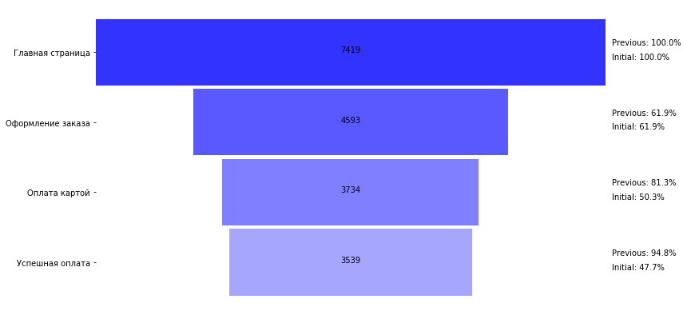

```python
fig, ax = plt.subplots(figsize=(12,7));

EventNameEng = ['MainScreenAppear', 'OffersScreenAppear', 'CartScreenAppear', 'PaymentScreenSuccessful']

for i in reversed(range(len(EventName))):
    ax.barh(EventName[i], unique_users.loc[EventNameEng[i], 'DeviceIDHash'], \
            height=0.95, align='center', left=(unique_users['DeviceIDHash'].max() - \
                                               unique_users.loc[EventNameEng[i], 'DeviceIDHash'])/2, \
            color='blue', alpha=(0.8-i*0.15))
    ax.annotate('Initial: ' + unique_users.loc[EventNameEng[i], 'Initial'], \
                xy=(unique_users['DeviceIDHash'].max() + 100, len(EventName) - i - 1.1), horizontalalignment='left')
    ax.annotate('Previous: ' + unique_users.loc[EventNameEng[i], 'Previous'], \
                xy=(unique_users['DeviceIDHash'].max() + 100, len(EventName) - i - 0.9), horizontalalignment='left')
    ax.annotate(unique_users.loc[EventNameEng[i], 'DeviceIDHash'], \
                xy=(unique_users['DeviceIDHash'].max()/2, len(EventName) - i-1), horizontalalignment='center')

ax.get_xaxis().set_visible(False)
ax.spines['top'].set_visible(False)
ax.spines['right'].set_visible(False)
ax.spines['bottom'].set_visible(False)
ax.spines['left'].set_visible(False)
fig.show();
```

**Вывод:** больше всего пользователей теряется на шаге оформления заказа — 38,1%. От первого события до оплаты доходит 47,7% пользователей.

### К оглавлению

## Шаг 5. Изучим результаты эксперимента

Посчитаем, сколько пользователей в каждой экспериментальной группе. Сгруппируем таблицу `logs_exp_filtered` по номерам экспериментов, посчитаем количество пользователей, сохраним в переменную `ExpId_users` и выведем на экран.

```python
ExpId_users = logs_exp_filtered.groupby('ExpId').agg({'DeviceIDHash': 'nunique'})
ExpId_users
```

| ExpId | DeviceIDHash |
| --- | --- |
| 246 | 2484 |
| 247 | 2513 |
| 248 | 2537 |

Создадим сводную таблицу `EventNumber`, сгруппируем данные по номерам эксперимента, в качестве столбцов — названия события, посчитаем количество пользователей и выведем на экран.

```python
EventNumber = logs_exp_filtered.pivot_table(
    index='ExpId', columns='EventName', values='DeviceIDHash', aggfunc='nunique')
EventNumber
```

| EventName ExpId | CartScreenAppear | MainScreenAppear | OffersScreenAppear | PaymentScreenSuccessful | Tutorial |
| --- | --- | --- | --- | --- | --- |
| 246 | 1266 | 2450 | 1542 | 1200 | 278 |
| 247 | 1238 | 2476 | 1520 | 1158 | 283 |
| 248 | 1230 | 2493 | 1531 | 1181 | 279 |

Создадим функцию `z_test_func`, которая проверяет нулевую гипотезу по статистической значимости различий и выводит результат.

```python
def z_test_func(first_exp, second_exp):
    """
    Функция получает на вход номера экспериментальных групп и название события, по котором идёт проверка нулевой гипотезы.
    Проверяет нулевую гипотезу по статистической значимости различий и выводит результат.

    """
    alpha = .05 # критический уровень статистической значимости

    EventName = ['MainScreenAppear', 'OffersScreenAppear', 'CartScreenAppear', 'PaymentScreenSuccessful']

    for i in EventName:
        # успехи
        successes = np.array([EventNumber.loc[first_exp, i], EventNumber.loc[second_exp, i]])

        # всего
        trials = np.array([ExpId_users.loc[first_exp, 'DeviceIDHash'], ExpId_users.loc[second_exp, 'DeviceIDHash']])

        # пропорция успехов в первой группе:
        p1 = successes[0]/trials[0]

        # пропорция успехов во второй группе:
        p2 = successes[1]/trials[1]

        # пропорция успехов в комбинированном датасете:
        p_combined = (successes[0] + successes[1]) / (trials[0] + trials[1])

        # разница пропорций в датасетах
        difference = p1 - p2

        # считаем статистику в ст.отклонениях стандартного нормального распределения
        z_value = difference / math.sqrt(p_combined * (1 - p_combined) * (1/trials[0] + 1/trials[1]))

        # задаем стандартное нормальное распределение (среднее 0, ст.отклонение 1)
        distr = st.norm(0, 1)

        p_value = (1 - distr.cdf(abs(z_value))) * 2

        print('p-значение: ', "{0:.3f}".format(p_value))

        if (p_value < alpha):
            print("Отвергаем нулевую гипотезу: между долями выборок", first_exp, "и", second_exp, "по событию", i, \
                  "есть значимая разница")
        else:
            print("Не получилось отвергнуть нулевую гипотезу, нет оснований считать доли выборок", first_exp, "и", \
                  second_exp, "по событию", i, "разными")
```

Проверим, находят ли статистические критерии разницу между выборками 246 и 247. Проверим по количеству событий успешной оплаты.

1. Сформулируем нулевую гипотезу:

H₀: нет оснований считать разными доли пользователей по каждому событию в выборках 246 и 247.

Hₐ: есть значимая разница между долями пользователей по каждому событию в выборках 246 и 247.

```python
z_test_func(246, 247)
```

```
p-значение:  0.757
Не получилось отвергнуть нулевую гипотезу, нет оснований считать доли выборок 246 и 247 по событию MainScreenAppear разными
p-значение:  0.248
Не получилось отвергнуть нулевую гипотезу, нет оснований считать доли выборок 246 и 247 по событию OffersScreenAppear разными
p-значение:  0.229
Не получилось отвергнуть нулевую гипотезу, нет оснований считать доли выборок 246 и 247 по событию CartScreenAppear разными
p-значение:  0.115
Не получилось отвергнуть нулевую гипотезу, нет оснований считать доли выборок 246 и 247 по событию PaymentScreenSuccessful разными
```

**Вывод:** разбиение на группы работает корректно. Доли пользователей по каждому событию в контрольных выборках одинаковые.

1. Сформулируем нулевую гипотезу:

H₀: нет оснований считать разными доли пользователей по каждому событию в выборках 246 и 248.

Hₐ: есть значимая разница между долями пользователей по каждому событию в выборках 246 и 248.

```python
z_test_func(246, 248)
```

```
p-значение:  0.295
Не получилось отвергнуть нулевую гипотезу, нет оснований считать доли выборок 246 и 248 по событию MainScreenAppear разными
p-значение:  0.208
Не получилось отвергнуть нулевую гипотезу, нет оснований считать доли выборок 246 и 248 по событию OffersScreenAppear разными
p-значение:  0.078
Не получилось отвергнуть нулевую гипотезу, нет оснований считать доли выборок 246 и 248 по событию CartScreenAppear разными
p-значение:  0.212
Не получилось отвергнуть нулевую гипотезу, нет оснований считать доли выборок 246 и 248 по событию PaymentScreenSuccessful разными
```

**Вывод:** Доли пользователей по каждому событию в контрольной выборке 246 и в экспериментальной выборке 248 одинаковые.

1. Сформулируем нулевую гипотезу:

H₀: нет оснований считать разными доли пользователей по каждому событию в выборках 247 и 248.

Hₐ: есть значимая разница между долями пользователей по каждому событию в выборках 247 и 248.

```python
z_test_func(247, 248)
```

```
p-значение:  0.459
Не получилось отвергнуть нулевую гипотезу, нет оснований считать доли выборок 247 и 248 по событию MainScreenAppear разными
p-значение:  0.920
Не получилось отвергнуть нулевую гипотезу, нет оснований считать доли выборок 247 и 248 по событию OffersScreenAppear разными
p-значение:  0.579
Не получилось отвергнуть нулевую гипотезу, нет оснований считать доли выборок 247 и 248 по событию CartScreenAppear разными
p-значение:  0.737
Не получилось отвергнуть нулевую гипотезу, нет оснований считать доли выборок 247 и 248 по событию PaymentScreenSuccessful разными
```

**Вывод:** Доли пользователей по каждому событию в контрольной выборке 247 и в экспериментальной выборке 248 одинаковые.

Объединим контрольные группы 246, 247 и сравним с экспериментальной группой 248. Добавим в таблицу `ExpId_users` суммарное число пользователей выборок 246 и 247 под индексом 246247.

```python
ExpId_users.loc[246247, 'DeviceIDHash'] = ExpId_users.loc[246, 'DeviceIDHash'] + ExpId_users.loc[247, 'DeviceIDHash']
ExpId_users
```

| ExpId | DeviceIDHash |
| --- | --- |
| 246 | 2484.0 |
| 247 | 2513.0 |
| 248 | 2537.0 |
| 246247 | 4997.0 |

Добавим в таблицу `EventNumber` суммарное число пользователей выборок 246 и 247 по каждому событию под индексом 246247.

```python
EventNumber.loc[246247, :] = EventNumber.loc[246, :] + EventNumber.loc[247, :]
EventNumber
```

| EventName ExpId | CartScreenAppear | MainScreenAppear | OffersScreenAppear | PaymentScreenSuccessful | Tutorial |
| --- | --- | --- | --- | --- | --- |
| 246 | 1266.0 | 2450.0 | 1542.0 | 1200.0 | 278.0 |
| 247 | 1238.0 | 2476.0 | 1520.0 | 1158.0 | 283.0 |
| 248 | 1230.0 | 2493.0 | 1531.0 | 1181.0 | 279.0 |
| 246247 | 2504.0 | 4926.0 | 3062.0 | 2358.0 | 561.0 |

1. Сформулируем нулевую гипотезу:

H₀: нет оснований считать разными доли пользователей по каждому событию в объединённой контрольной группе 246, 247 и экспериментальной группе 248.

Hₐ: есть значимая разница между долями пользователей по каждому событию в объединённой контрольной группе 246, 247 и экспериментальной группе 248.

```python
z_test_func(246247, 248)
```

```
p-значение:  0.294
Не получилось отвергнуть нулевую гипотезу, нет оснований считать доли выборок 246247 и 248 по событию MainScreenAppear разными
p-значение:  0.434
Не получилось отвергнуть нулевую гипотезу, нет оснований считать доли выборок 246247 и 248 по событию OffersScreenAppear разными
p-значение:  0.182
Не получилось отвергнуть нулевую гипотезу, нет оснований считать доли выборок 246247 и 248 по событию CartScreenAppear разными
p-значение:  0.600
Не получилось отвергнуть нулевую гипотезу, нет оснований считать доли выборок 246247 и 248 по событию PaymentScreenSuccessful разными
```

**Вывод:** доли пользователей по каждому событию в объединённой контрольной группе 246, 247 и экспериментальной группе 248 одинаковые.

### Общий вывод: тест следует признать неуспешным. Доли пользователей по каждому событию в контрольных группах и экспериментальной группе одинаковые.

При проверке статистических гипотез выше был выбран уровень значимости 0.05. Было сделано 16 проверок статистических гипотез. Уровень значимости меньше 0.1, не будем его менять.

**Проверим результаты эксперимента критерием Манна-Уитни.**

Найдём количество уникальных пользователей и совершённых ими событий. Сгруппируем таблицу `logs_exp_filtered` по пользователям, посчитаем количество событий, сбросим индексы методом `reset_index()`, сохраним в переменную `logs_exp_filtered_users`.

```python
logs_exp_filtered_users = logs_exp_filtered.groupby('DeviceIDHash').agg({'EventName': 'count'}).reset_index()
logs_exp_filtered_users
```

|  | DeviceIDHash | EventName |
| --- | --- | --- |
| 0 | 6888746892508752 | 1 |
| 1 | 6909561520679493 | 5 |
| 2 | 6922444491712477 | 47 |
| 3 | 7435777799948366 | 6 |
| 4 | 7702139951469979 | 137 |
| ... | ... | ... |
| 7529 | 9217594193087726423 | 9 |
| 7530 | 9219463515465815368 | 17 |
| 7531 | 9220879493065341500 | 6 |
| 7532 | 9221926045299980007 | 7 |
| 7533 | 9222603179720523844 | 59 |

7534 rows × 2 columns

Создадим сводную таблицу `logs_exp_filtered_246`, сгруппируем данные из выборки 246 по пользователям, посчитаем общее количество событий по каждому из них, сбросим индексы методом `reset_index()`, выведем на экран.

```python
logs_exp_filtered_246 = logs_exp_filtered[logs_exp_filtered['ExpId'] == 246].\
pivot_table(index='DeviceIDHash', columns='EventName', values='ExpId', aggfunc='count').reset_index()
logs_exp_filtered_246.head(5)
```

| EventName | DeviceIDHash | CartScreenAppear | MainScreenAppear | OffersScreenAppear | PaymentScreenSuccessful | Tutorial |
| --- | --- | --- | --- | --- | --- | --- |
| 0 | 6888746892508752 | NaN | 1.0 | NaN | NaN | NaN |
| 1 | 6922444491712477 | 8.0 | 19.0 | 12.0 | 8.0 | NaN |
| 2 | 8740973466195562 | NaN | 8.0 | 1.0 | NaN | NaN |
| 3 | 12692216027168046 | NaN | 7.0 | 3.0 | NaN | NaN |
| 4 | 15708180189885246 | 38.0 | 27.0 | 38.0 | 23.0 | NaN |

Создадим сводную таблицу `logs_exp_filtered_247`, сгруппируем данные из выборки 247 по пользователям, посчитаем общее количество событий по каждому из них, сбросим индексы методом `reset_index()`, выведем на экран.

```python
logs_exp_filtered_247 = logs_exp_filtered[logs_exp_filtered['ExpId'] == 247].\
pivot_table(index='DeviceIDHash', columns='EventName', values='ExpId', aggfunc='count').reset_index()
logs_exp_filtered_247.head(5)
```

| EventName | DeviceIDHash | CartScreenAppear | MainScreenAppear | OffersScreenAppear | PaymentScreenSuccessful | Tutorial |
| --- | --- | --- | --- | --- | --- | --- |
| 0 | 6909561520679493 | 1.0 | 2.0 | 1.0 | 1.0 | NaN |
| 1 | 7702139951469979 | 5.0 | 40.0 | 87.0 | 5.0 | NaN |
| 2 | 28534696657485531 | 6.0 | 11.0 | 7.0 | 5.0 | NaN |
| 3 | 28755862496905658 | 2.0 | 6.0 | NaN | NaN | NaN |
| 4 | 29094035245869447 | 2.0 | 10.0 | 10.0 | 1.0 | 1.0 |

Создадим сводную таблицу `logs_exp_filtered_248`, сгруппируем данные из выборки 248 по пользователям, посчитаем общее количество событий по каждому из них, сбросим индексы методом `reset_index()`, выведем на экран.

```python
logs_exp_filtered_248 = logs_exp_filtered[logs_exp_filtered['ExpId'] == 248].\
pivot_table(index='DeviceIDHash', columns='EventName', values='ExpId', aggfunc='count').reset_index()
logs_exp_filtered_248.head(5)
```

| EventName | DeviceIDHash | CartScreenAppear | MainScreenAppear | OffersScreenAppear | PaymentScreenSuccessful | Tutorial |
| --- | --- | --- | --- | --- | --- | --- |
| 0 | 7435777799948366 | NaN | 6.0 | NaN | NaN | NaN |
| 1 | 8486814028069281 | 4.0 | 4.0 | 2.0 | NaN | NaN |
| 2 | 9841258664663090 | 8.0 | 10.0 | 8.0 | 2.0 | 1.0 |
| 3 | 26317307137967461 | NaN | 5.0 | NaN | NaN | NaN |
| 4 | 27899413433550864 | NaN | 9.0 | NaN | NaN | NaN |

*Примечание: бывает, что количество событий успешной оплаты больше количества переходов на главную страницу. Неполные данные?*

```python
logs_exp_filtered_246[logs_exp_filtered_246['PaymentScreenSuccessful'] > logs_exp_filtered_246['MainScreenAppear']].head()
```

| EventName | DeviceIDHash | CartScreenAppear | MainScreenAppear | OffersScreenAppear | PaymentScreenSuccessful | Tutorial |
| --- | --- | --- | --- | --- | --- | --- |
| 5 | 18658818197810381 | 7.0 | 3.0 | 63.0 | 6.0 | NaN |
| 24 | 91292479590032512 | 45.0 | 30.0 | 28.0 | 36.0 | NaN |
| 56 | 197027893265565660 | 931.0 | 93.0 | 107.0 | 865.0 | NaN |
| 71 | 263550556164486172 | 13.0 | 3.0 | 9.0 | 10.0 | NaN |
| 92 | 366093607806007780 | 35.0 | 13.0 | 7.0 | 32.0 | NaN |

Добавим к таблице уникальных пользователей `logs_exp_filtered_users` столбцы из выборки 246 по пользователям `logs_exp_filtered_246`. Добавим столбец `Total` — отношение числа успешной оплаты к общему числу событий, заменим пропуски нулями методом `fillna()`. Выведем пять строк на экран.

```python
sample_246 = logs_exp_filtered_users.merge(logs_exp_filtered_246, on='DeviceIDHash', how='left')
sample_246['Total'] = (sample_246['PaymentScreenSuccessful'] / sample_246['EventName']).fillna(0)
sample_246.sample(5)
```

|  | DeviceIDHash | EventName | CartScreenAppear | MainScreenAppear | OffersScreenAppear | PaymentScreenSuccessful | Tutorial | Total |
| --- | --- | --- | --- | --- | --- | --- | --- | --- |
| 1515 | 1902634890028391543 | 38 | NaN | NaN | NaN | NaN | NaN | 0.0 |
| 7074 | 8652127031019540255 | 191 | NaN | NaN | NaN | NaN | NaN | 0.0 |
| 5667 | 7033128542556787609 | 7 | NaN | NaN | NaN | NaN | NaN | 0.0 |
| 2917 | 3662441162486667021 | 25 | NaN | NaN | NaN | NaN | NaN | 0.0 |
| 3366 | 4231316200676149778 | 47 | NaN | NaN | NaN | NaN | NaN | 0.0 |

Добавим к таблице уникальных пользователей `logs_exp_filtered_users` столбцы из выборки 247 по пользователям `logs_exp_filtered_246`. Добавим столбец `Total` — отношение числа успешной оплаты к общему числу событий, заменим пропуски нулями методом `fillna()`. Выведем пять строк на экран.

```python
sample_247 = logs_exp_filtered_users.merge(logs_exp_filtered_247, on='DeviceIDHash', how='left')
sample_247['Total'] = (sample_247['PaymentScreenSuccessful'] / sample_247['EventName']).fillna(0)
sample_247.sample(5)
```

|  | DeviceIDHash | EventName | CartScreenAppear | MainScreenAppear | OffersScreenAppear | PaymentScreenSuccessful | Tutorial | Total |
| --- | --- | --- | --- | --- | --- | --- | --- | --- |
| 2647 | 3357371372909105330 | 9 | NaN | NaN | NaN | NaN | NaN | 0.000000 |
| 187 | 250419112136655315 | 56 | 7.0 | 13.0 | 30.0 | 6.0 | NaN | 0.107143 |
| 6552 | 8059769296163008703 | 13 | NaN | 13.0 | NaN | NaN | NaN | 0.000000 |
| 3021 | 3794977356240836925 | 107 | NaN | NaN | NaN | NaN | NaN | 0.000000 |
| 3088 | 3881891539348553720 | 17 | 1.0 | 8.0 | 7.0 | 1.0 | NaN | 0.058824 |

Добавим к таблице уникальных пользователей `logs_exp_filtered_users` столбцы из выборки 248 по пользователям `logs_exp_filtered_246`. Добавим столбец `Total` — отношение числа успешной оплаты к общему числу событий, заменим пропуски нулями методом `fillna()`. Выведем пять строк на экран.

```python
sample_248 = logs_exp_filtered_users.merge(logs_exp_filtered_248, on='DeviceIDHash', how='left')
sample_248['Total'] = (sample_248['PaymentScreenSuccessful'] / sample_248['EventName']).fillna(0)
sample_248.sample(5)
```

|  | DeviceIDHash | EventName | CartScreenAppear | MainScreenAppear | OffersScreenAppear | PaymentScreenSuccessful | Tutorial | Total |
| --- | --- | --- | --- | --- | --- | --- | --- | --- |
| 6661 | 8183993768433290804 | 12 | NaN | NaN | NaN | NaN | NaN | 0.0 |
| 6220 | 7670816421888043072 | 3 | NaN | 3.0 | NaN | NaN | NaN | 0.0 |
| 2550 | 3226469711415915535 | 5 | NaN | NaN | NaN | NaN | NaN | 0.0 |
| 475 | 634894491679664239 | 31 | NaN | NaN | NaN | NaN | NaN | 0.0 |
| 2272 | 2862153300066037949 | 21 | NaN | NaN | NaN | NaN | NaN | 0.0 |

```python
alpha = .05 # критический уровень статистической значимости
```

Сформулируем следующие гипотезы.

H₀: нет статистически значимой разницы в количестве событий успешной оплаты между выборками 246 и 247.

Hₐ: есть статистически значимая разница в количестве событий успешной оплаты между выборками 246 и 247.

```python
results = st.mannwhitneyu(sample_246['Total'], \
                          sample_247['Total'])

print('p-значение: ', "{0:.3f}".format(results.pvalue))

if (results.pvalue < alpha):
    print("Отвергаем нулевую гипотезу: разница статистически значима")
else:
    print("Не получилось отвергнуть нулевую гипотезу, вывод о различии сделать нельзя")
```

```
p-значение:  0.141
Не получилось отвергнуть нулевую гипотезу, вывод о различии сделать нельзя
```

Сформулируем следующие гипотезы.

H₀: нет статистически значимой разницы в количестве событий успешной оплаты между выборками 246 и 248.

Hₐ: есть статистически значимая разница в количестве событий успешной оплаты между выборками 246 и 248.

```python
results = st.mannwhitneyu(sample_246['Total'], \
                          sample_248['Total'])

print('p-значение: ', "{0:.3f}".format(results.pvalue))

if (results.pvalue < alpha):
    print("Отвергаем нулевую гипотезу: разница статистически значима")
else:
    print("Не получилось отвергнуть нулевую гипотезу, вывод о различии сделать нельзя")
```

```
p-значение:  0.379
Не получилось отвергнуть нулевую гипотезу, вывод о различии сделать нельзя
```

Сформулируем следующие гипотезы.

H₀: нет статистически значимой разницы в количестве событий успешной оплаты между выборками 247 и 248.

Hₐ: есть статистически значимая разница в количестве событий успешной оплаты между выборками 247 и 248.

```python
results = st.mannwhitneyu(sample_247['Total'], \
                          sample_248['Total'])

print('p-значение: ', "{0:.3f}".format(results.pvalue))

if (results.pvalue < alpha):
    print("Отвергаем нулевую гипотезу: разница статистически значима")
else:
    print("Не получилось отвергнуть нулевую гипотезу, вывод о различии сделать нельзя")
```

```
p-значение:  0.225
Не получилось отвергнуть нулевую гипотезу, вывод о различии сделать нельзя
```

**Вывод:** тест следует признать неуспешным. Изменение шрифта не повлияло на количество событий успешной оплаты.

### К оглавлению

## Выводы

**Тест следует признать неуспешным. Доли пользователей по каждому событию в контрольных группах и экспериментальной группе одинаковые. Изменение шрифта не повлияло на количество событий успешной оплаты.**

В датасете 243713 события, уникальных событий всего пять:

- `MainScreenAppear` — переход на главную страницу;
- `OffersScreenAppear` — переход на страницу оформления заказа;
- `CartScreenAppear` — переход на страницу оплаты картой;
- `PaymentScreenSuccessful` — переход на страницу успешной оплаты;
- `Tutorial` — обучение.

В логе всего 7551 пользователь, чаще всего на пользователя приходится 5 событий.

Данные полны с 1-го августа 2019, в полных данных есть пользователи из всех трёх экспериментальных групп. Количество отброшенных событий и пользователей составляет 1% данных.

Пользователи чаще всего обновляют главную страницу, что вполне очевидно. Больше всего пользователей теряется на шаге оформления заказа — 38,1%. От первого события до оплаты доходит 47,7% пользователей.

Разбиение на группы работает корректно.

### К оглавлению